# 3_ML

Team 1 (Destroyers): Jesus Vazquez, Leo Li, Ying Zhang, Tian Zhao

4/8/2021

As mentioned in the notes, Support Vector Machines (SVM) and Random Forest, are two popular methods for binary classification. In this part of the code we will show how to derive the results from our report. We will be diving this section into (1) training and (2) results.

## Importing Data

```r
library(RANN)
library(caret)
library(kernlab)
library(e1071)
library(dplyr)
set.seed(1)

# training set
dat <- read.csv("..//1-Data//train_cc.csv")[,-1] # deleting observation number variable
#test set
test <- read.csv("..//1-Data/test.csv")[,-1]
xtest <- test %>% select(-c("target"))
ytest <- test %>% select(c("target"))
```

## 1. Train Model

Due to the class imbalance in our outcome variables in addition to the (1) unweighted SVM and Random Forest, we will conduct the analysis using (2) down-sampling with the SVM and Random Forest, and (2) weighted SVM. These three variations will be compared to illustrate overall performance between all competing models.

### Down Sampling

When using down-sampling we will select all of the observations in the minority class. In this case `target = 1`. Then, random sampling is used in the majority class, `target = 0`, to select at most an equal number observations as in the minority class. The SVM method will have a linear kernel, a $C$-grid ranging between 1 to 10. The RF will use 500 trees, and a mtry (number of randomly sampled vectors) randing between 1 to 52. The best models will be selected using the Cohen’s Kappa Statistic.

```r
# downsample
down_dat <- read.csv("..//1-Data//train_cc_downsample.csv")[,-c(1,2)]

# Define X and y
y <- ifelse(down_dat$target == "1", "yes","no") # transform variable to factor
x <- down_dat %>% select(-'target')

library(parallel)
# Calculate the number of cores
no_cores <- detectCores() - 1

library(doParallel)
# create the cluster for caret to use
cl <- makePSOCKcluster(no_cores)
registerDoParallel(cl)

train_control <- trainControl(method="cv", number=5, search="grid",
                              allowParallel = TRUE, classProbs = TRUE)

# SVM Linear
mygrid2 = expand.grid(C = seq(1,10, length=10))
fit1down <- train(x,y,method="svmLinear",
              trControl = train_control,
              metric = 'Kappa', tuneGrid = mygrid2)
# Random Forest
tunegrid <- expand.grid(.mtry = (1:(dim(dat)[2]-1)))
fit2down <- train(x,y,method="rf",
              trControl=train_control,
              metric = 'Kappa',
              tuneGrid = tunegrid)
stopCluster(cl)
registerDoSEQ()
```

The results for the SVM using the down-sample are below. The best model considered a $C$-value of 8.

```r
fit1down
```

```
## Support Vector Machines with Linear Kernel
##
## 2072 samples
##   52 predictor
##    2 classes: 'no', 'yes'
##
## No pre-processing
## Resampling: Cross-Validated (5 fold)
## Summary of sample sizes: 1658, 1657, 1658, 1657, 1658
## Resampling results across tuning parameters:
##
##   C   Accuracy   Kappa
##    1  0.7138141  0.4276173
##    2  0.7147791  0.4295463
##    3  0.7138129  0.4276112
##    4  0.7138129  0.4276140
##    5  0.7133298  0.4266450
##    6  0.7128479  0.4256793
##    7  0.7142960  0.4285802
##    8  0.7147791  0.4295463
##    9  0.7138129  0.4276083
##   10  0.7138129  0.4276140
##
## Kappa was used to select the optimal model using the largest value.
## The final value used for the model was C = 8.
```

The results for the Random Forest using the down-sample are below. The best model considered an mtry of 3.

```r
fit2down
```

```
## Random Forest
##
## 2072 samples
##   52 predictor
##    2 classes: 'no', 'yes'
##
## No pre-processing
## Resampling: Cross-Validated (5 fold)
## Summary of sample sizes: 1657, 1657, 1658, 1658, 1658
## Resampling results across tuning parameters:
##
##   mtry  Accuracy   Kappa
##    1    0.6814702  0.3629496
##    2    0.7109179  0.4218323
##    3    0.7200966  0.4401956
```

[output cut: 52 more lines]

### Weighted

As previously mentioned, high class imbalance can make it difficult for classification methods to predict an outcome variable and can also increase computational time when searching for an optimal model. This is specially true for Linear SVM since we would have to search through a cost grid ranging between 1 to 3000 to find an optimal model whose Kappa statistic is not 0. In this part we show the implementation of the algorithm where the weight is selected to be the inverse of the proportion of observations with `target=1`. The $C$-grid will vary between 1 to 10 and will also include the inverse of the proportion of observations with `target=0`.

```r
y <- ifelse(dat$target == "1", "yes","no") # transform variable to factor
x <- dat %>% select(-'target')

library(parallel)
# Calculate the number of cores
no_cores <- detectCores() - 1

library(doParallel)
# create the cluster for caret to use
cl <- makePSOCKcluster(no_cores)
registerDoParallel(cl)

train_control <- trainControl(method="cv", number=5, search="grid",
                              allowParallel = TRUE, classProbs = TRUE)

# SVM Linear Weight
myweight <- mean(dat$target, na.rm = TRUE) # add weight
mygridw = expand.grid(cost = c(1/(1-myweight),seq(1,10, length=10)), weight = c(1/myweight)) # specify weight
fit1w <- train(x,y,method="svmLinearWeights",
              trControl = train_control,
              metric = 'Kappa', tuneGrid = mygridw)
```

The results for the weighted SVM indicate that the values used for best model are $C=1$ when weight is 6.0675.

```r
fit1w
```

```
## Linear Support Vector Machines with Class Weights
##
## 6286 samples
##   52 predictor
##    2 classes: 'no', 'yes'
##
## No pre-processing
## Resampling: Cross-Validated (5 fold)
## Summary of sample sizes: 5029, 5029, 5028, 5029, 5029
## Resampling results across tuning parameters:
##
##   cost       Accuracy   Kappa
##    1.000000  0.7807818  0.3509006
##    1.197333  0.7807818  0.3509006
##    2.000000  0.7806227  0.3506463
##    3.000000  0.7806227  0.3506463
##    4.000000  0.7806227  0.3506463
##    5.000000  0.7806227  0.3506463
##    6.000000  0.7806227  0.3506463
##    7.000000  0.7807818  0.3509006
##    8.000000  0.7803046  0.3492596
##    9.000000  0.7806229  0.3492654
##   10.000000  0.7796686  0.3468992
##
## Tuning parameter 'weight' was held constant at a value of 6.067568
## Kappa was used to select the optimal model using the largest value.
## The final values used for the model were cost = 1 and weight = 6.067568.
```

### Unweighted

On this part of the document we present the implementation of the RF and SVM unweighted. Again, the RF uses 500 trees and an mtry-grid ranging between 1 and 52. The SVM uses the linear kernel, a $C$-grid ranging between 1 to 3000. From previous analyses it was found that the $C$ that maximizes the Kappa statistic is 1578.94. For computational purposes we will only run the model with C=1578.94, but if one can uncomment the previous line and re-run the code to confirm results.

```r
library(parallel)
# Calculate the number of cores
no_cores <- detectCores() - 1

library(doParallel)
# create the cluster for caret to use
cl <- makePSOCKcluster(no_cores)
registerDoParallel(cl)

train_control <- trainControl(method="cv", number=5, search="grid",
                              allowParallel = TRUE, classProbs = TRUE)
# SVM Linear
# mygrid = expand.grid(C=seq(1,3000,length=20))
mygrid = expand.grid(C=1578.94)
fit1 <- train(x,y,method="svmLinear",
              trControl = train_control,
              metric = 'Kappa', tuneGrid = mygrid)
# Random Forest
# tunegrid <- expand.grid(.mtry = (1:(dim(dat)[2]-1)))
tunegrid <- expand.grid(.mtry = 11)
fit2 <- train(x,y, method="rf",
              trControl=train_control,
              metric = 'Kappa', tuneGrid = tunegrid)

stopCluster(cl)
registerDoSEQ()
```

The results for the SVM are presented below.

```r
fit1
```

```
## Support Vector Machines with Linear Kernel
##
## 6286 samples
##   52 predictor
##    2 classes: 'no', 'yes'
##
## No pre-processing
## Resampling: Cross-Validated (5 fold)
## Summary of sample sizes: 5029, 5029, 5028, 5029, 5029
## Resampling results:
##
##   Accuracy  Kappa
##   0.824692  0.1162751
##
## Tuning parameter 'C' was held constant at a value of 1578.94
```

The results for the RF are presented below. The optimal model picked `mtry=11`.

```r
fit2
```

```
## Random Forest
##
## 6286 samples
##   52 predictor
##    2 classes: 'no', 'yes'
##
## No pre-processing
## Resampling: Cross-Validated (5 fold)
## Summary of sample sizes: 5029, 5029, 5028, 5029, 5029
## Resampling results:
##
##   Accuracy  Kappa
##   0.855075  0.3845454
##
## Tuning parameter 'mtry' was held constant at a value of 11
```

### Test

After we have trained the models using the methods previously discussed we predict the outcomes using the test-set. We write `type=prob` so that the predicted values are probabilities, instead of 0 or 1.

```r
# Down-Sample SVM Linear
ypredictSVM_down <- predict(fit1down,xtest, type = "prob")
# Down-Sample RF
ypredictRF_down <- predict(fit2down,xtest, type = "prob")
# Weighted SVM Linear
ypredictSVM_weight <- predict(fit1w,xtest, type = "prob")
# SVM Linear
ypredictSVM <- predict(fit1,xtest, type = "prob")
# RF
ypredictRF <- predict(fit2,xtest, type = "prob")
```

## 2. Results

### ROC

```r
library(ROCR)
library(pROC)

# load the test dataset
res_pred <- as.data.frame(test$target)
res_pred$rf_down <- ypredictRF_down$yes
res_pred$svm_down <- ypredictSVM_down$yes
res_pred$svm_weight <- ypredictSVM_weight$yes
res_pred$svm_uw <- ypredictSVM$yes
res_pred$rf_uw <- ypredictRF$yes

# calculate the AUC value
auc = matrix(ncol=2,nrow=5)
auc[1,] <- cbind("RF - Down Sample", auc(res_pred$`test$target`,res_pred$rf_down) %>% round(3))
auc[2,] <- cbind("SVM Down Sample", auc(res_pred$`test$target`,res_pred$svm_down) %>% round(3))
auc[3,] <- cbind("RF - Unweighted", auc(res_pred$`test$target`,res_pred$rf_uw) %>% round(3))
auc[4,] <- cbind("SVM - Unweighted", auc(res_pred$`test$target`,res_pred$rf_uw) %>% round(3))
auc[5,] <- cbind("SVM - Weighted", auc(res_pred$`test$target`,res_pred$svm_weight) %>% round(3))
kableExtra::kable(auc)
```

[output not shown]

[figure not shown]

```r
# generate the preds dataset for ROC curve
preds_rf_down = prediction(res_pred$rf_down, res_pred$`test$target`)
preds_svm_down = prediction(res_pred$svm_down, res_pred$`test$target`)
preds_rf_uw = prediction(res_pred$rf_uw, res_pred$`test$target`)
preds_svm_uw = prediction(res_pred$svm_uw, res_pred$`test$target`)
preds_svm_weight = prediction(res_pred$svm_weight, res_pred$`test$target`)
perf_rf_down = performance(preds_rf_down,"tpr","fpr")
perf_svm_down = performance(preds_svm_down,"tpr","fpr")
perf_rf_uw = performance(preds_rf_uw,"tpr","fpr")
perf_svm_uw = performance(preds_svm_uw,"tpr","fpr")
perf_svm_weight = performance(preds_svm_weight,"tpr","fpr")
plot(perf_rf_down,col=10,lty=2 , main="ROC curves: by machine learning methods")
plot(perf_svm_down,col=4,lty=2, add = TRUE)
plot(perf_rf_uw,col=10, add = TRUE)
plot(perf_svm_uw,col=4,add = TRUE )
plot(perf_svm_weight,col =1, lty=4, add = TRUE )
abline(0,1)
op <- par(cex = 1)
legend("bottomright",c("Weighted SVM","RF down","SVM down","RF unweight","SVM unweight"),col=c("black","red","blue","red","blue"), lty = c(2,2,1,1,4))
```

### Variable Importance

Variable importance was also a point of interest in this research study. The top 3 most important variables are plotted for each of the methods considered.

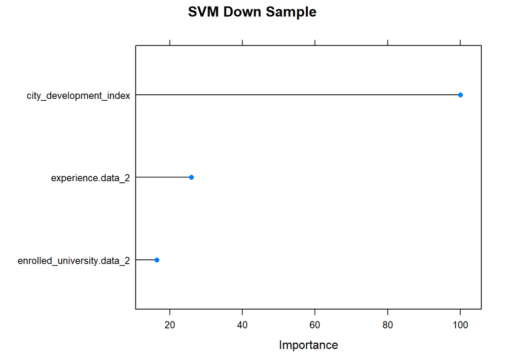

```r
# Down-Sample SVM Linear
svmimp_down = varImp(fit1down)
plot(svmimp_down, top = 3, main = "SVM Down Sample")
```

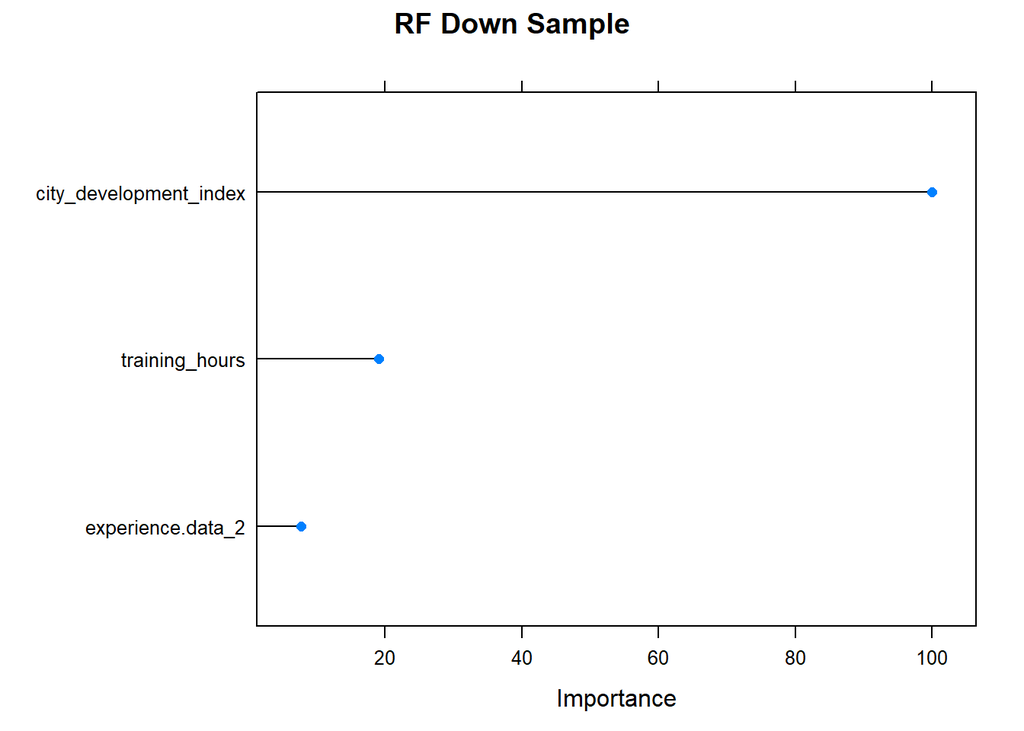

```r
# Down-Sample RF
rfimp_down = varImp(fit2down)
plot(rfimp_down, top = 3, main = "RF Down Sample")
```

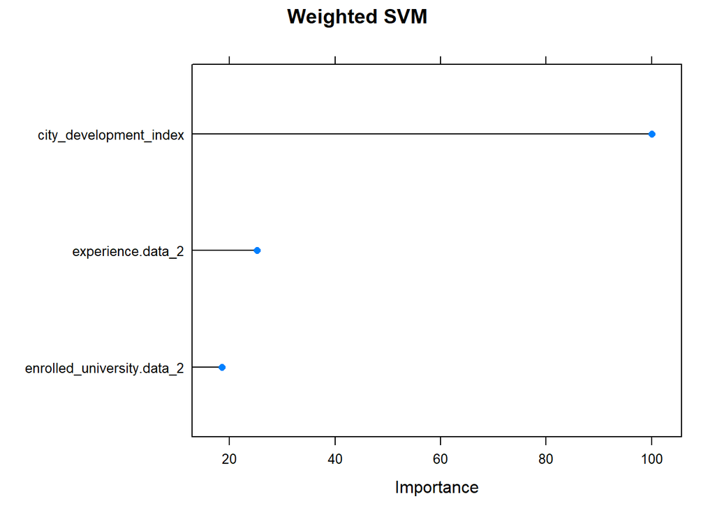

```r
# Weighted SVM Linear
svmimp_linear = varImp(fit1w)
plot(svmimp_linear, top = 3, main = "Weighted SVM")
```

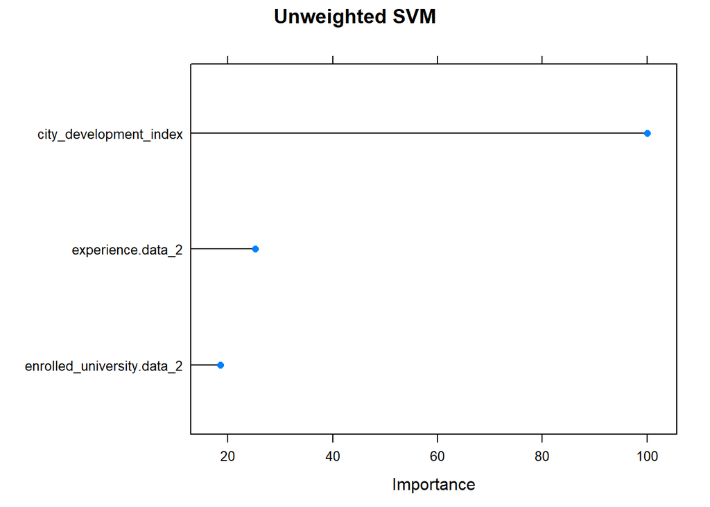

```r
# SVM Linear
svmimp = varImp(fit1)
plot(svmimp, top = 3, main = "Unweighted SVM")
```

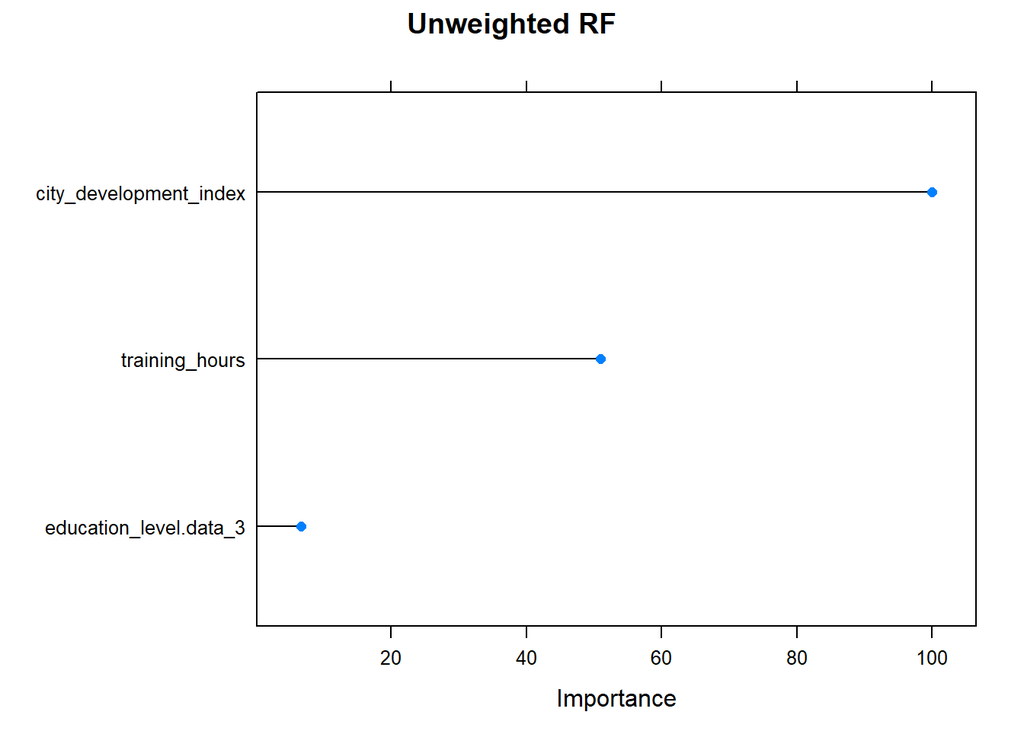

```r
# RF
rfimp = varImp(fit2)
plot(rfimp, top = 3, main = "Unweighted RF")
```